# Preparing your files for tagging

### **Before we start**

The goal of this tutorial is to teach you how to prepare your files for tagging using either the CROW tool or the AntLab tools. You will need to download:

**1. Corpus Text Processor from [CROW](https://writecrow.org/)**

- In order to run the tagger, you will need to convert and standardize your text. For this, we will use the [Corpus Text Processor](https://github.com/writecrow/ciabatta/wiki/1.-Tools:-Corpus-Text-Processor#installation). You can read more about it [here](https://github.com/writecrow/ciabatta/wiki/1.-Tools:-Corpus-Text-Processor)

**2. [AntLab Tools](https://www.laurenceanthony.net/software.html)**

- If you need to convert files from Word or PDF to .txt, download the [AntConverter](https://www.laurenceanthony.net/software/antfileconverter/)
- To make sure your files are in the correct encoding, download [EncodeAnt](https://www.laurenceanthony.net/software/encodeant/)

For both programs, remember to download the correct tool for your computer’s operational system.

### **Overview**

In this tutorial, I will explain how to use both the Corpus Text Processor from [CROW](https://writecrow.org/) and the [AntLab Tools](https://www.laurenceanthony.net/software.html), but you should choose only one.

1.Corpus Text Processor from [CROW](https://writecrow.org/)  
2.[AntLab Tools](https://www.laurenceanthony.net/software.html)

#### **1. [Corpus Text Processor](https://github.com/writecrow/ciabatta/wiki/1.-Tools:-Corpus-Text-Processor#installation)**

We will use CROW’s Corpus Text Processor to prepare the files. I recommend that you create three folders in your computer that mirror the menus in the Corpus Text Processor: 01_converted, 02_encoded, and 03_standardized before running the tool. It should look like this.

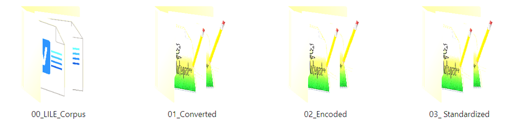

And this is what you will see when you open the Corpus Text Processor

[figure not shown]

To convert the files, we should follow the order of the menus in the Corpus Text Processor. You can also watch the [video demonstration](https://drive.google.com/file/d/1xMiHrJzF1L5kjS3wVGVIF8OmlQQ5iI4q/view) on how to run it.

#### **2. [AntLab Tools](https://www.laurenceanthony.net/software.html)**

##### **2.1. Converting**

- Open AntFileConverter
- Select the directory where your files are.

`File> Open Dir..`

[figure not shown]

[figure not shown]

- Press **Start**

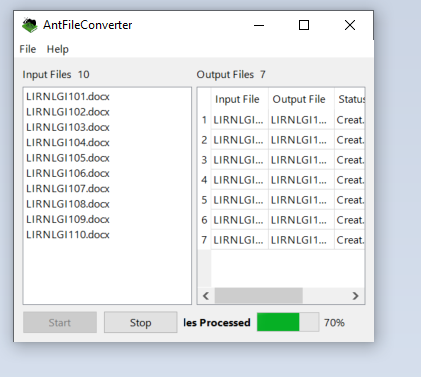

#### **2.2. Encoding**

- Open EncodeAnt

[figure not shown]

- Select the directory where your files are.

`File> Open File(s)/Open Dir..`

[figure not shown]

- Click on Convert to UTF-8

[figure not shown]

- Press **Start**

###### Send us the converted and encoded files for tagging